# ml1

Anusha Bhat

2025-02-03

## Data Loading

```r
df = read.csv("german_credit_hw1.csv")
```

```r
# make categorical columns factors
df$CheckingAccountStatus = factor(df$CheckingAccountStatus)
df$CreditHistory = factor(df$CreditHistory)
df$Purpose = factor(df$Purpose)
df$Savings = factor(df$Savings)
df$EmploymentStatus = factor(df$EmploymentStatus)
df$PersonalStatus = factor(df$PersonalStatus)
df$OtherDebtors = factor(df$OtherDebtors)
df$PropertyStatus = factor(df$PropertyStatus)
df$InstallmentPlansStatus = factor(df$InstallmentPlansStatus)
df$HousingStatus = factor(df$HousingStatus)
df$JobStatus = factor(df$JobStatus)
```

## Split Data Into Train and Test Sets

For the simulation, we chose to use all of the variables after feature engineering the one-hot encoded boolean columns since all of the features are relevant for predicting Amount.

```r
# Split the data into train and test using 632:368 ratio
shuffled_indices = sample(nrow(df))
train_indices = shuffled_indices[1:632]
test_indices = shuffled_indices[633:1000]

df_train = df[train_indices, ]
df_test = df[test_indices, ]
```

## Run Full Model Linear Regression on Train Data

```r
# Run lm on whole data frame
lm_full = lm(Amount ~ ., data = df_train)
full_model_coeffs = coef(lm_full)
```

```r
summary(lm_full)
```

```
##
## Call:
## lm(formula = Amount ~ ., data = df_train)
##
## Residuals:
##     Min      1Q  Median      3Q     Max
## -4551.3 -1050.5  -102.1   771.5 11264.5
##
## Coefficients:
##                            Estimate Std. Error t value Pr(>|t|)
## (Intercept)               3020.4807   972.2841   3.107 0.001985 **
## X                           -0.1658     0.2564  -0.647 0.517935
## Duration                   132.0609     7.0797  18.654  < 2e-16 ***
## InstallmentRatePercentage -821.0665    69.4630 -11.820  < 2e-16 ***
## ResidenceDuration           25.2170    76.3953   0.330 0.741453
## Age                          8.3930     7.7645   1.081 0.280168
## NumberExistingCredits      182.7101   161.0108   1.135 0.256938
## NumberPeopleMaintenance   -257.0363   217.3561  -1.183 0.237465
## Telephone                 -560.6939   169.4146  -3.310 0.000992 ***
## ForeignWorker             -317.0554   422.3012  -0.751 0.453087
## CheckingAccountStatus1     -12.0782   200.6510  -0.060 0.952021
## CheckingAccountStatus2     193.4123   197.4304   0.980 0.327665
## CheckingAccountStatus3    -870.1501   325.6190  -2.672 0.007744 **
## CreditHistory1            -218.2328   315.6342  -0.691 0.489582
## CreditHistory2            -115.8684   211.4229  -0.548 0.583873
## CreditHistory3             465.1825   282.8956   1.644 0.100640
## Purpose1                   852.5002   284.7646   2.994 0.002873 **
## Purpose2                  -155.1062   240.3228  -0.645 0.518917
## Purpose3                  -402.4120   216.2501  -1.861 0.063266 .
## Purpose4                  -891.1133   681.3430  -1.308 0.191429
## Purpose5                   210.1330   597.0812   0.352 0.725015
## Purpose6                  -434.1549   362.2905  -1.198 0.231262
## Purpose8                  -501.6830   689.2455  -0.728 0.466983
## Purpose9                   -24.9640   308.7443  -0.081 0.935584
## Purpose10                 1447.0414   777.2771   1.862 0.063150 .
## Savings1                  -499.0181   271.8747  -1.835 0.066944 .
## Savings2                  -475.7393   313.3238  -1.518 0.129464
## Savings3                  -124.8661   405.6547  -0.308 0.758334
## Savings4                    99.9783   207.0067   0.483 0.629297
## EmploymentStatus1         -138.6036   226.8615  -0.611 0.541463
```

[output cut: 9 more lines]

```
## PropertyStatus2             50.4534   208.4056   0.242 0.808794
## PropertyStatus3            782.8259   366.8636   2.134 0.033272 *
## InstallmentPlansStatus1   -234.0831   381.1858  -0.614 0.539394
## InstallmentPlansStatus2     41.1993   221.0265   0.186 0.852196
## HousingStatus1              48.4509   214.1357   0.226 0.821076
## HousingStatus2             -56.5893   419.2091  -0.135 0.892666
## JobStatus1                 314.0314   599.0166   0.524 0.600307
## JobStatus2                 291.5340   580.3871   0.502 0.615639
## JobStatus3                1567.9310   577.5381   2.715 0.006827 **
## ---
## Signif. codes:  0 '***' 0.001 '**' 0.01 '*' 0.05 '.' 0.1 ' ' 1
##
## Residual standard error: 1831 on 584 degrees of freedom
## Multiple R-squared:  0.622,  Adjusted R-squared:  0.5915
## F-statistic: 20.44 on 47 and 584 DF,  p-value: < 2.2e-16
```

## Simulating Linear Regression 1000 times

```r
# Function to run linear regression 1000 times
sim_regs = function(df, n_runs = 1000) {

  # Fit the model once to determine the number of coefficients
  # Need to do this since there are many dummy variables
  model_example = lm(Amount ~ ., data = df)

  # Get the names of the coefficients from the model
  coef_names = names(coef(model_example))

  n_predictors = length(coef_names)

  # Initialize results matrix
  # + 2 for R-squared columns
  results = matrix(NA, nrow = n_runs, ncol = n_predictors + 2)

  colnames(results) = c(coef_names, "R_squared_train", "R_squared_test")

  # Run the 1000 iterations
  for (i in 1:n_runs) {

    # Split the shuffled data into train and test
    shuffled_indices = sample(nrow(df))
    train_indices = shuffled_indices[1:632]
    test_indices = shuffled_indices[633:1000]

    df_train = df[train_indices, ]
    df_test = df[test_indices, ]


    # Train model and store the coefficients and R-squareds
    model = lm(Amount ~ ., data = df_train)
    results[i, 1:n_predictors] = coef(model)
    r_squared_train = summary(model)$r.squared


    # Predict on the test data for test R-squared
    test_predictions = predict(model, newdata = df_test)
    test_actual_values = df_test$Amount
    test_residuals = test_actual_values - test_predictions
    ss_total_test = sum((test_actual_values - mean(test_actual_values))^2)
    ss_residual_test = sum(test_residuals^2)
    r_squared_test = 1 - (ss_residual_test / ss_total_test)

    # Store R-squared values in the last 2 columns
    results[i, n_predictors + 1] = r_squared_train
    results[i, n_predictors + 2] = r_squared_test
  }

  return(results)
}
```

```r
# Run simulation 1000 times
results_matrix = sim_regs(df)

# Convert to data frame
res_df = as.data.frame(results_matrix)

head(results_matrix)
```

```
##      (Intercept)           X Duration InstallmentRatePercentage
## [1,]     208.565 -0.13296526 135.1493                 -767.6919
## [2,]    2503.589 -0.14704289 127.4501                 -777.0525
## [3,]    2193.238 -0.06513276 126.8039                 -801.8875
## [4,]    2194.410 -0.22146724 133.5379                 -845.1743
## [5,]    3526.267 -0.02817105 123.2226                 -746.6905
## [6,]    2942.377  0.11455669 128.4386                 -860.3369
##      ResidenceDuration       Age NumberExistingCredits NumberPeopleMaintenance
## [1,]         22.360140 17.424947             199.03018               -56.71893
## [2,]         14.528790  2.696486              72.96061              -521.76398
## [3,]        -10.845965  7.706513             103.28120                92.99121
## [4,]        -23.998632 14.754035             211.96343               -82.96299
## [5,]         -6.401941  1.021204              18.01014              -308.80537
## [6,]        -27.255209  3.204053             202.53199              -353.85116
##      Telephone ForeignWorker CheckingAccountStatus1 CheckingAccountStatus2
```

[output cut: 69 more lines]

## Plotting the Distributions of any 10 Coefficients, Train $R^2$, Test $R^2$, and Percentage Decrease of $R^2$.

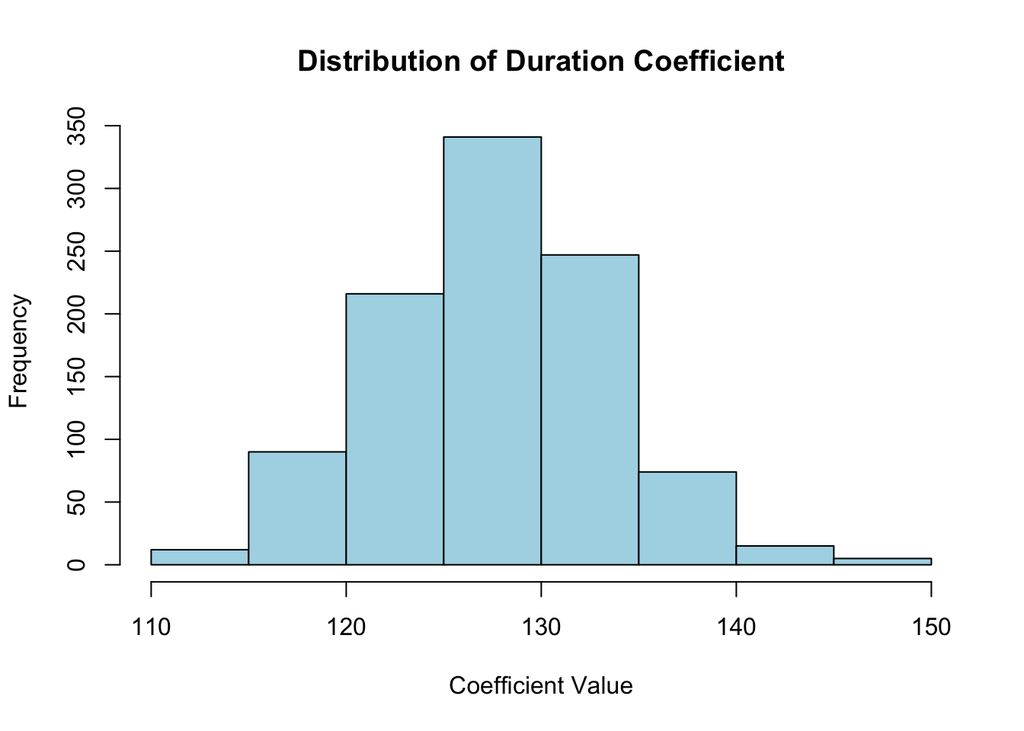

```r
hist(res_df$Duration, main = "Distribution of Duration Coefficient",
     xlab = "Coefficient Value",
     col = "light blue")
```

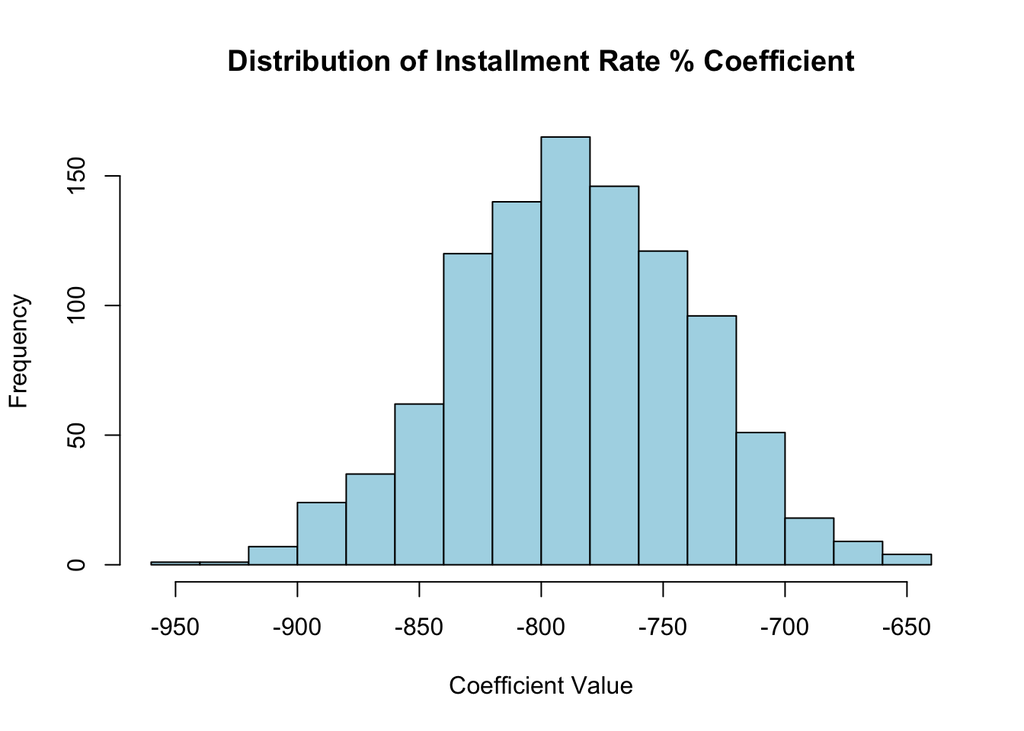

```r
hist(res_df$InstallmentRatePercentage,
     main = "Distribution of Installment Rate % Coefficient",
     xlab = "Coefficient Value",
     col = "light blue")
```

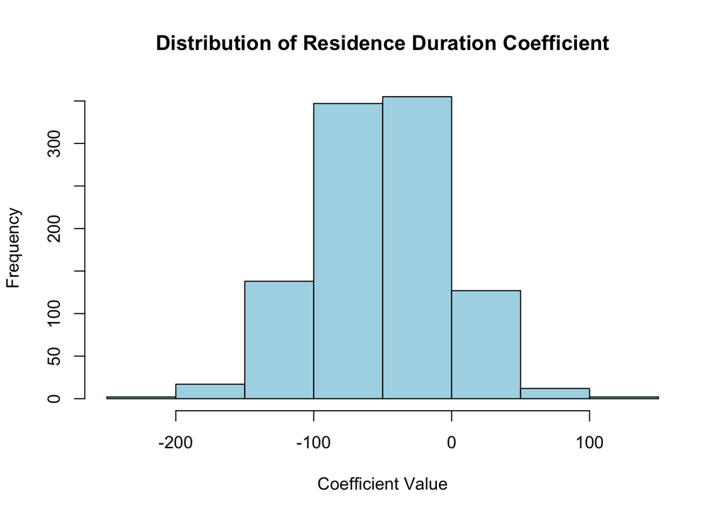

```r
hist(res_df$ResidenceDuration,
     main = "Distribution of Residence Duration Coefficient",
     xlab = "Coefficient Value",
     col = "light blue")
```

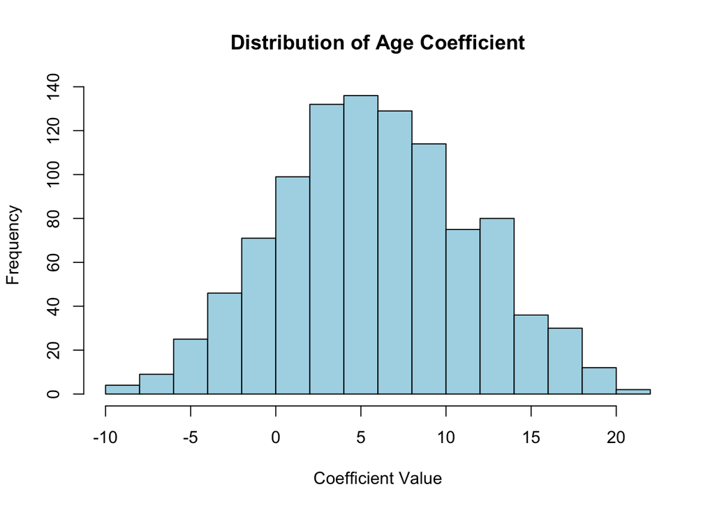

```r
hist(res_df$Age, main = "Distribution of Age Coefficient",
     xlab = "Coefficient Value",
     col = "light blue")
```

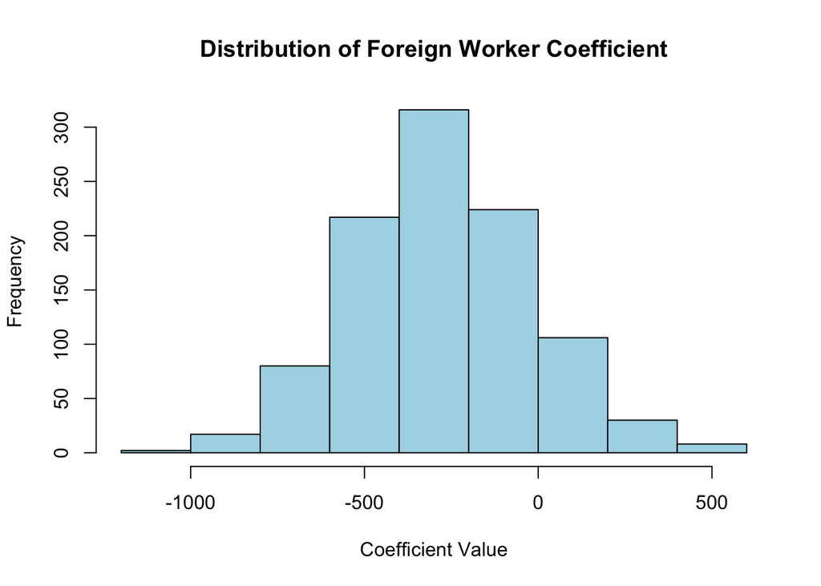

```r
hist(res_df$ForeignWorker,
     main = "Distribution of Foreign Worker Coefficient",
     xlab = "Coefficient Value",
     col = "light blue")
```

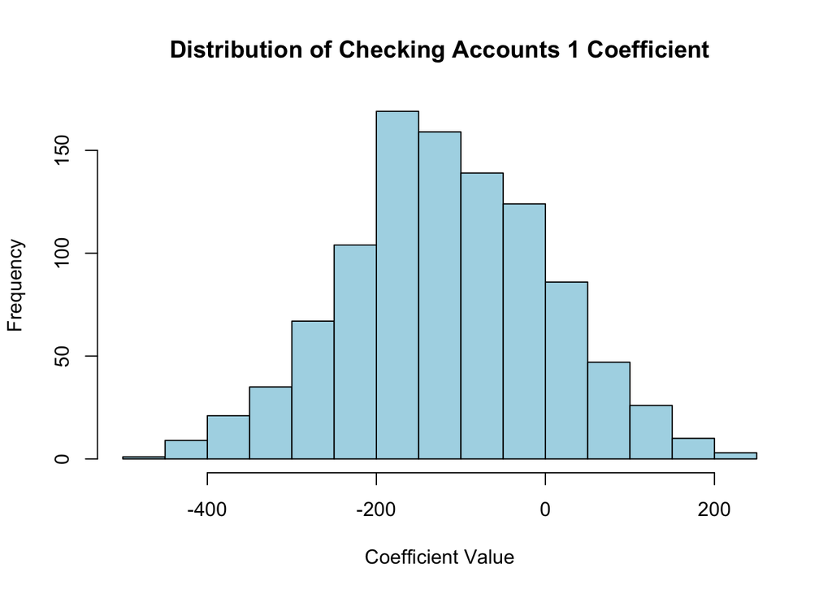

```r
hist(res_df$CheckingAccountStatus1,
     main = "Distribution of Checking Accounts 1 Coefficient",
     xlab = "Coefficient Value",
     col = "light blue")
```

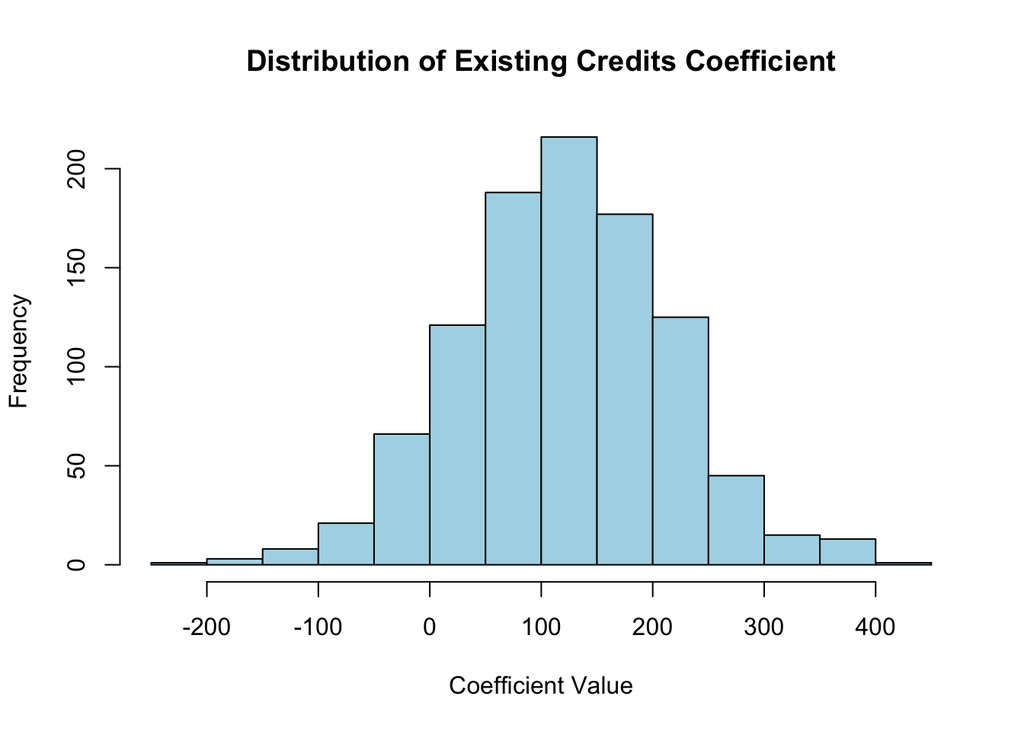

```r
hist(res_df$NumberExistingCredits,
     main = "Distribution of Existing Credits Coefficient",
     xlab = "Coefficient Value",
     col = "light blue")
```

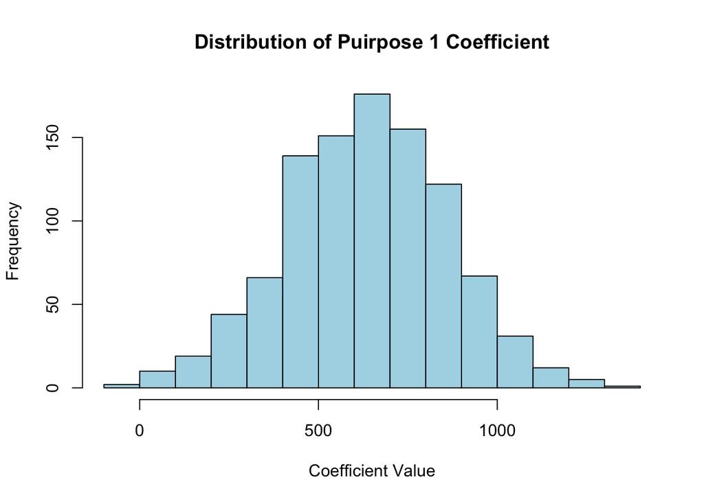

```r
hist(res_df$Purpose1,
     main = "Distribution of Puirpose 1 Coefficient",
     xlab = "Coefficient Value",
     col = "light blue")
```

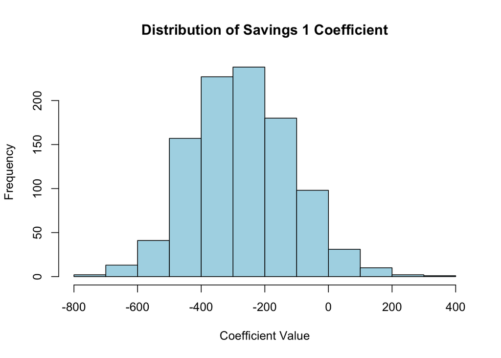

```r
hist(res_df$Savings1,
     main = "Distribution of Savings 1 Coefficient",
     xlab = "Coefficient Value",
     col = "light blue")
```

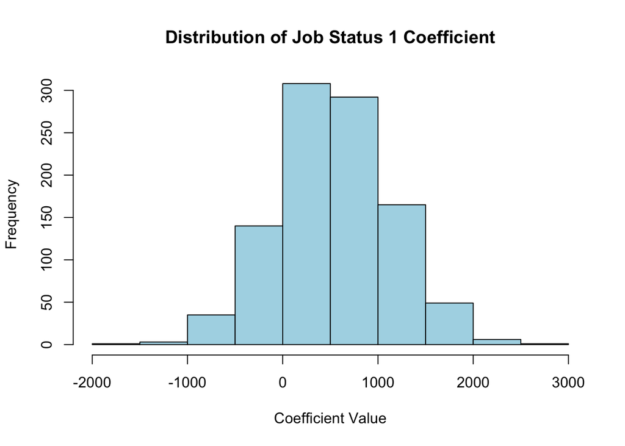

```r
hist(res_df$JobStatus1,
     main = "Distribution of Job Status 1 Coefficient",
     xlab = "Coefficient Value",
     col = "light blue")
```

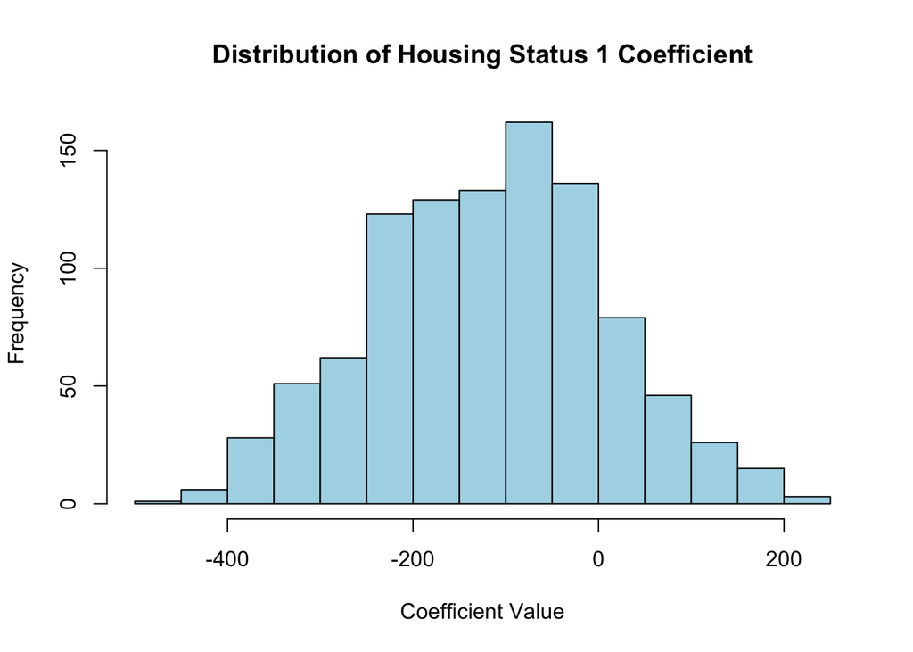

```r
hist(res_df$HousingStatus1,
     main = "Distribution of Housing Status 1 Coefficient",
     xlab = "Coefficient Value",
     col = "light blue")
```

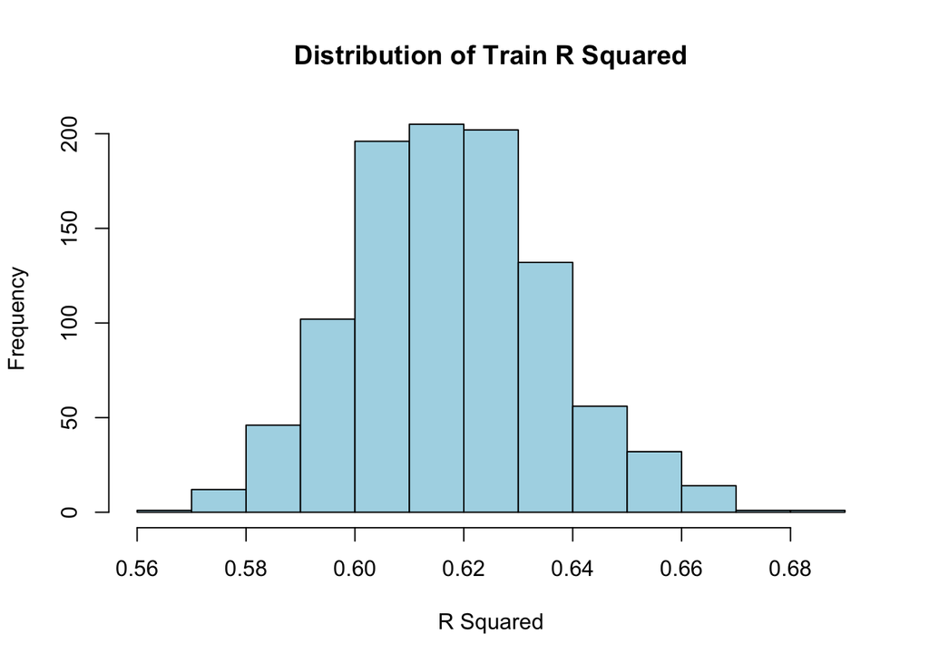

```r
hist(res_df$R_squared_train,
     main = "Distribution of Train R Squared",
     xlab = "R Squared",
     col = "light blue")
```

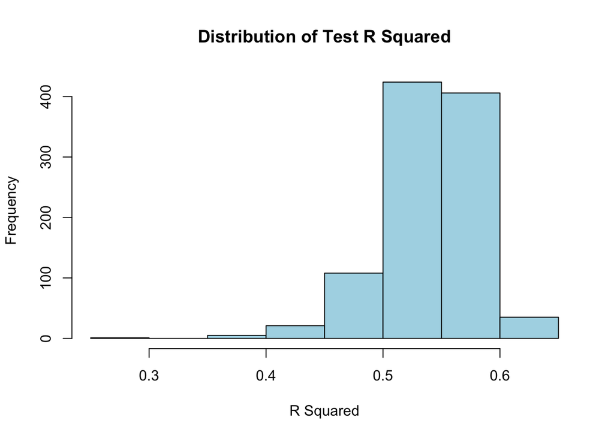

```r
hist(res_df$R_squared_test,
     main = "Distribution of Test R Squared",
     xlab = "R Squared",
     col = "light blue")
```

```r
# Calculate percentage change in R2
fall_r2 = (res_df$R_squared_train - res_df$R_squared_test) / res_df$R_squared_train * 100
```

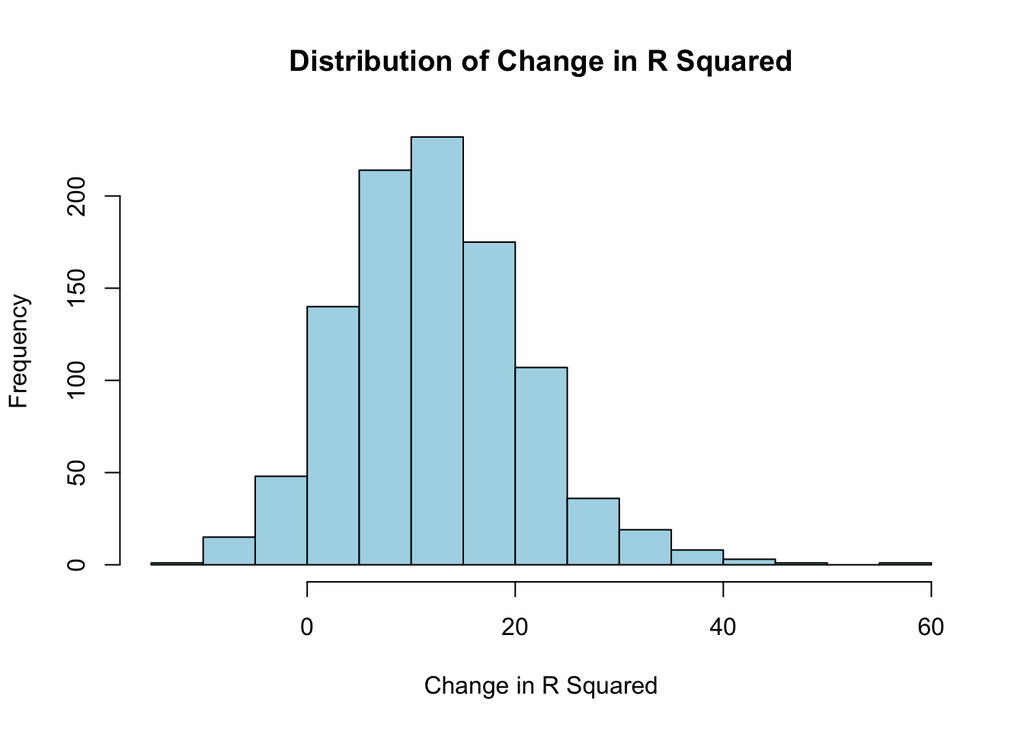

```r
hist(fall_r2,
     main = "Distribution of Change in R Squared",
     xlab = "Change in R Squared",
     col = "light blue")
```

```r
# Table of R^2 in train, test, and change

tmp_df = cbind(res_df$R_squared_train, res_df$R_squared_test, fall_r2)
colnames(tmp_df) = c("Train R Squared", "Test R Squared", "Percentage Drop")
head(as.data.frame(tmp_df), 20)
```

```
##    Train R Squared Test R Squared Percentage Drop
## 1        0.6423610      0.5043546      21.4842378
## 2        0.6098749      0.5719830       6.2130592
## 3        0.6172874      0.5517104      10.6234179
## 4        0.6334862      0.5049768      20.2860647
## 5        0.6196714      0.5507981      11.1144963
## 6        0.6109555      0.5598204       8.3696918
## 7        0.6234976      0.5447437      12.6309906
## 8        0.6156446      0.5643579       8.3305737
## 9        0.6061796      0.5618770       7.3084965
## 10       0.5970275      0.5943771       0.4439218
## 11       0.5851479      0.5781880       1.1894210
## 12       0.6104199      0.5537418       9.2850928
## 13       0.5991176      0.5792137       3.3221918
## 14       0.6694818      0.4499486      32.7915083
## 15       0.6468492      0.4668481      27.8273741
## 16       0.6550082      0.4183910      36.1243108
## 17       0.6246442      0.5382790      13.8263017
## 18       0.5932422      0.5996435      -1.0790241
## 19       0.5837097      0.5843770      -0.1143248
## 20       0.6437378      0.4915949      23.6342951
```

The train $R^2$ is higher than the test $R^2$ which is what we usually expect since the model is fit using the train data so it should predict better using the train data than the test data. The percentage change histogram is concentrated between 5-20% which is a reasonable change from the train to test $R^2$ value since we expect test $R^2$ to be slightly lower than train $R^2$ for a decent model, indicating a good result. We usually expect train $R^2$ to be higher than what we observe in the train $R^2$ histogram above, however, since we don’t observe a large change between train and test $R^2$, this is a reasonable result.

## Comparing Averages and Standard Deviationss

```r
# Remove R^2 columns
coef_df = res_df[, 1:(ncol(res_df)-2)]

# Calculate means and standard deviations
coeff_means = as.data.frame(colMeans(coef_df))
coeff_sds = as.data.frame(apply(coef_df, 2, sd))
```

```r
# Compare avg to full model by calculating percentage difference
mean_pct = (abs(full_model_coeffs - coeff_means)/((coeff_means + full_model_coeffs)/2)) * 100
```

```r
# Table of Means, Standard Deviation
tmp_df2 = cbind(coeff_means, coeff_sds, full_model_coeffs, mean_pct)
colnames(tmp_df2) = c("Means", "SDs", "Full Model", "Difference")
tmp_df2
```

```
##                                   Means          SDs   Full Model  Difference
## (Intercept)               2540.89351615  864.7386470 3020.4807107   17.247075
## X                            0.02579602    0.1707658   -0.1658448 -273.677247
## Duration                   127.68495541    5.7380093  132.0609293    3.369427
## InstallmentRatePercentage -786.63839113   48.4088627 -821.0664732   -4.282886
## ResidenceDuration          -50.91829323   48.3869339   25.2170495 -592.464269
## Age                          5.85060093    5.6352482    8.3929840   35.698640
## NumberExistingCredits      120.63424430   94.7618794  182.7100859   40.927643
## NumberPeopleMaintenance   -213.45047993  130.8434246 -257.0362712  -18.527957
## Telephone                 -478.87890239  109.6117424 -560.6939209  -15.740123
## ForeignWorker             -274.01702472  259.4399884 -317.0554004  -14.562810
## CheckingAccountStatus1    -116.94694814  120.3633445  -12.0781623 -162.555623
## CheckingAccountStatus2     227.94833009  120.0802194  193.4123480   16.392598
## CheckingAccountStatus3    -615.22415021  144.3971691 -870.1501136  -34.324812
## CreditHistory1              82.30936440  208.4459687 -218.2327779 -442.222770
## CreditHistory2             -10.90200160  121.9878992 -115.8684304 -165.600806
## CreditHistory3             350.42488705  202.1746823  465.1824629   28.140398
## Purpose1                   634.32399539  226.5821467  852.5001556   29.347944
## Purpose2                   -78.37762896  139.3722487 -155.1061596  -65.724932
## Purpose3                  -316.46460549  117.2875236 -402.4120284  -23.911592
## Purpose4                  -724.99566334  313.0298227 -891.1132756  -20.557725
## Purpose5                    86.61279648  325.5259833  210.1329580   83.249826
## Purpose6                  -161.20236524  241.2973287 -434.1548951  -91.693693
## Purpose8                  -465.72218417  493.6584890 -501.6830411   -7.434497
## Purpose9                  -187.13911889  189.2578617  -24.9640229 -152.920975
## Purpose10                 1762.16893216 1147.2672967 1447.0413774   19.638947
## Savings1                  -269.32976866  156.1931695 -499.0180513  -59.787580
## Savings2                  -346.02886374  158.5836239 -475.7393040  -31.568621
## Savings3                  -115.88639689  171.3023777 -124.8660579   -7.459663
## Savings4                   311.37728399  144.1690641   99.9783070  102.781623
## EmploymentStatus1          -53.32780832  124.6485694 -138.6035966  -88.860693
## EmploymentStatus2          -26.16637791  145.9563645 -282.4017374 -166.080257
## EmploymentStatus3         -277.93308921  152.7997013 -319.4635530  -13.903816
## EmploymentStatus4         -117.94610050  311.9873584 -231.4646380  -64.977132
## PersonalStatus1           -173.20597408  238.9543344 -217.5315424  -22.688156
## PersonalStatus2            281.31113805  239.5527278  154.3059264   58.310485
## PersonalStatus3           -456.92868217  255.6160517 -501.9171145   -9.383872
## OtherDebtors1              562.16049352  254.3703087  963.2284375   52.585663
## OtherDebtors2             -176.39907839  169.6104654 -408.7653499  -79.419138
## PropertyStatus1            271.77855963  112.3767789  179.8876370   40.689750
## PropertyStatus2            279.77571838  105.2325529   50.4533947  138.886800
## PropertyStatus3            843.82958164  301.2746833  782.8259485    7.500498
## InstallmentPlansStatus1     60.50013951  288.4919753 -234.0831310 -339.414902
## InstallmentPlansStatus2    185.23372260  141.9923930   41.1992790  127.220363
## HousingStatus1            -116.78616053  125.7269252   48.4509215 -483.607241
## HousingStatus2            -246.55330524  377.9837250  -56.5892961 -125.329801
## JobStatus1                 535.06089550  596.6366297  314.0313943   52.062539
## JobStatus2                 491.25097310  602.4187332  291.5339997   51.027289
## JobStatus3                1731.35810133  627.9154969 1567.9309660    9.906809
```

## Confidence Intervals

```r
full_model_ci = confint(lm_full)
full_model_ci_df = as.data.frame(full_model_ci)
colnames(full_model_ci_df) = c("Full_Lower_Bound", "Full_Upper_Bound")
```

```r
# Matrix for CI results (lower bound, upper bound, CI width)
ci_matrix = matrix(NA, nrow = ncol(coef_df), ncol = 3)

# Loop through each coefficient and get CI bounds
for (i in 1:ncol(coef_df)) {

  # Calculate the lower (25th percentile) and upper (97.5th percentile) bounds
  coef_values = sort(coef_df[[i]])
  lower_bound = coef_values[round(0.025 * length(coef_values))]
  upper_bound = coef_values[round(0.975 * length(coef_values))]

  ci_matrix[i, 1] = lower_bound
  ci_matrix[i, 2] = upper_bound

  # Calculate the width of the CI
  ci_width = (upper_bound - lower_bound) * sqrt(0.632)

  ci_matrix[i, 3] = ci_width
}


ci_df = as.data.frame(ci_matrix)
colnames(ci_df) = c("Lower_Bound", "Upper_Bound", "CI_Width")
rownames(ci_df) = colnames(coef_df)
```

```r
# Calculate the width of the confidence intervals for the full model
full_model_ci_width = full_model_ci_df$Full_Upper_Bound - full_model_ci_df$Full_Lower_Bound
```

```r
# Results df for CIs
combined_ci_df = cbind(ci_df, full_model_ci_df)
combined_ci_df$Full_CI_Width = full_model_ci_width

# Column indicating if simulated coef has larger or smaller CI than full model coef
combined_ci_df$CI_Comparison = ifelse(combined_ci_df$CI_Width < combined_ci_df$Full_CI_Width, "Smaller", "Larger")

combined_ci_df
```

```
##                             Lower_Bound  Upper_Bound     CI_Width
## (Intercept)                 790.6423040 4248.1169633 2748.6379908
## X                            -0.3053217    0.3471834    0.5187313
## Duration                    116.3775040  138.9630083   17.9551208
## InstallmentRatePercentage  -885.4943948 -697.1005832  149.7701181
## ResidenceDuration          -147.6893195   42.8989954  151.5147137
## Age                          -5.0232707   16.8239707   17.3682134
## NumberExistingCredits       -73.2911413  304.8831253  300.6425958
## NumberPeopleMaintenance    -465.3062679   37.2946871  399.5598566
## Telephone                  -684.4439939 -275.2765544  325.2816809
## ForeignWorker              -782.6623302  240.1308923  813.1045301
## CheckingAccountStatus1     -358.2359718  117.9263011  378.5415201
## CheckingAccountStatus2      -22.5515807  455.3000764  379.8845539
## CheckingAccountStatus3     -912.9738538 -351.9827038  445.9791435
## CreditHistory1             -338.7480179  497.5748430  664.8635246
## CreditHistory2             -252.9079346  225.4018485  380.2487569
## CreditHistory3              -56.7854256  742.9877294  635.8070831
## Purpose1                    177.3434720 1050.8837584  694.4507926
## Purpose2                   -331.1730119  193.0447430  416.7448726
## Purpose3                   -538.3063318  -83.8881650  361.2552976
## Purpose4                  -1344.4815488 -107.7169936  983.2083751
## Purpose5                   -588.6569692  695.3855862 1020.7936420
## Purpose6                   -632.8830098  316.5175488  754.7585163
## Purpose8                  -1384.2797790  550.5521651 1538.1609734
## Purpose9                   -574.0531407  165.8149001  588.1834592
## Purpose10                  -478.4034512 4044.5235148 3595.6558220
## Savings1                   -563.7391355   39.3784304  479.4689818
## Savings2                   -672.2657371  -57.0498082  489.0869901
## Savings3                   -466.5348010  221.5673014  547.0303520
## Savings4                     23.5693965  603.4374827  460.9860110
## EmploymentStatus1          -282.8651127  182.7930504  370.1909179
## EmploymentStatus2          -325.6480023  243.9088871  452.7887718
## EmploymentStatus3          -579.1787961   26.4104808  481.4339532
## EmploymentStatus4          -723.2080062  486.3764895  961.6006553
## PersonalStatus1            -644.0520074  298.6006228  749.3940193
## PersonalStatus2            -167.9018797  762.8406440  739.9256719
## PersonalStatus3            -943.3874397   77.8906619  811.9000328
## OtherDebtors1                67.4920694 1038.2313104  771.7224332
## OtherDebtors2              -519.9319128  143.6989001  527.5760618
## PropertyStatus1              44.5251453  490.1396750  354.2565446
```

[output cut: 92 more lines]

```
## PersonalStatus1                 Smaller
## PersonalStatus2                 Smaller
## PersonalStatus3                 Smaller
## OtherDebtors1                   Smaller
## OtherDebtors2                   Smaller
## PropertyStatus1                 Smaller
## PropertyStatus2                 Smaller
## PropertyStatus3                 Smaller
## InstallmentPlansStatus1         Smaller
## InstallmentPlansStatus2         Smaller
## HousingStatus1                  Smaller
## HousingStatus2                  Smaller
## JobStatus1                      Smaller
## JobStatus2                      Smaller
## JobStatus3                      Smaller
```

```r
# Count how many are smaller or larger
comparison_counts = table(combined_ci_df$CI_Comparison)
comparison_counts
```

```
##
##  Larger Smaller
##       1      47
```

The results for the means show that less than half of the coefficients had a percentage difference of less than 30%, indicating a large difference between the mean and full model coefficients. Most confidence intervals (CIs) from the ensemble method were narrower (47) compared to the full model, with only 1 wider. As the number of samples increases, such as with 10,000, we expect the CIs to tighten, providing more precise estimates. Since the ensemble method was run 1,000 times compared to the full model’s single run, it produces more reliable and accurate confidence intervals, as expected with repeated sampling.

## ML part

```r
# dot prod avg coeffs w/ test df and compare preds w/ actual Amount col to get R2 and compare that w/ R2 from full model
```

```r
# Create predictions using the full model formula structure
train_matrix <- model.matrix(lm_full)
test_matrix <- model.matrix(Amount ~ ., data = df_test)

# Ensure the coefficient names align with the matrix columns
coeff_names <- names(coef(lm_full))
ensemble_coeffs <- coeff_means[coeff_names, ]

# Make predictions
train_preds <- as.matrix(train_matrix) %*% as.matrix(ensemble_coeffs)
test_preds <- as.matrix(test_matrix) %*% as.matrix(ensemble_coeffs)

# Calculate R-squared for ensemble model
calc_r2 <- function(actual, predicted) {
    residuals <- actual - predicted
    ss_residual <- sum(residuals^2)
    ss_total <- sum((actual - mean(actual))^2)
    return(1 - ss_residual/ss_total)
}

# Calculate R-squared for ensemble model
ensemble_train_r2 <- calc_r2(df_train$Amount, train_preds)
ensemble_test_r2 <- calc_r2(df_test$Amount, test_preds)

# Get R-squared for single OLS model (your full model)
ols_train_r2 <- summary(lm_full)$r.squared
ols_test_preds <- predict(lm_full, newdata = df_test)
ols_test_r2 <- calc_r2(df_test$Amount, ols_test_preds)

cat("Single OLS Model:\n")
```

```
## Single OLS Model:
```

```r
cat("Train R-squared:", round(ols_train_r2, 4), "\n")
```

```
## Train R-squared: 0.622
```

```r
cat("Test R-squared:", round(ols_test_r2, 4), "\n\n")
```

```
## Test R-squared: 0.5415
```

```r
cat("Ensemble Model (Average of 1000 models):\n")
```

```
## Ensemble Model (Average of 1000 models):
```

```r
cat("Train R-squared:", round(ensemble_train_r2, 4), "\n")
```

```
## Train R-squared: 0.6113
```

```r
cat("Test R-squared:", round(ensemble_test_r2, 4), "\n")
```

```
## Test R-squared: 0.5957
```

While the single OLS model fits the training data better, the ensemble model provides improved predictive performance on the test data. This demonstrates the effectiveness of the ensemble approach in machine learning, emphasizing the importance of using multiple models to achieve better generalization.